### 1. GitHub Cloning (20 points): Using Git, clone the following GitHub repository to your local machine: https://github.com/caesar0301/awesome-public-datasets. In RMarkdown, please show the code (commented out, as it’s not R syntax) that you used to create a new directory, navigate to the appropriate directory, and clone the repository to it. One Git command per line, please.

```
<!-- Navigating to the appropriate directory -->
sojha@71F5M32 MINGW64 ~
$ cd ~/Desktop/

sojha@71F5M32 MINGW64 ~/Desktop
<!-- Cloning the repo into my desktop repo -->
$ git clone https://github.com/caesar0301/awesome-public-datasets
Cloning into 'awesome-public-datasets'...
remote: Enumerating objects: 21, done.
remote: Counting objects: 100% (21/21), done.
remote: Compressing objects: 100% (9/9), done.
remote: Total 1758 (delta 12), reused 21 (delta 12), pack-reused 1737
Receiving objects: 100% (1758/1758), 661.01 KiB | 43.00 KiB/s, done.
Resolving deltas: 100% (1047/1047), done.


<!-- Navigating to the directory to look at the content -->
sojha@71F5M32 MINGW64 ~/Desktop
$ cd awesome-public-datasets

sojha@71F5M32 MINGW64 ~/Desktop/awesome-public-datasets (master)
$ ls
Datasets/  LICENSE  README.rst
```

### 2a. In R, please read in titanic.csv via either read.table() or read.csv(), assigning it to df. This dataset follows the passengers aboard the Titanic, including their fees paid, rooms rented, and survivorship status.

```r
getwd()
```

```
## [1] "C:/Users/sojha.WVOFFICE.000/Documents/SMU/Summer 2019/Doing Data Science/Wk 3 HW"
```

```r
titanic <- read.csv("titanic.csv",TRUE,",")
class(titanic)
```

```
## [1] "data.frame"
```

### 2b. Output the respective count of females and males aboard the Titanic. Plot the frequency of females and males. Be sure to give an accurate title and label the axes.

```r
as.data.frame(table(titanic$Sex))
```

```
##     Var1 Freq
## 1 female  314
## 2   male  577
```

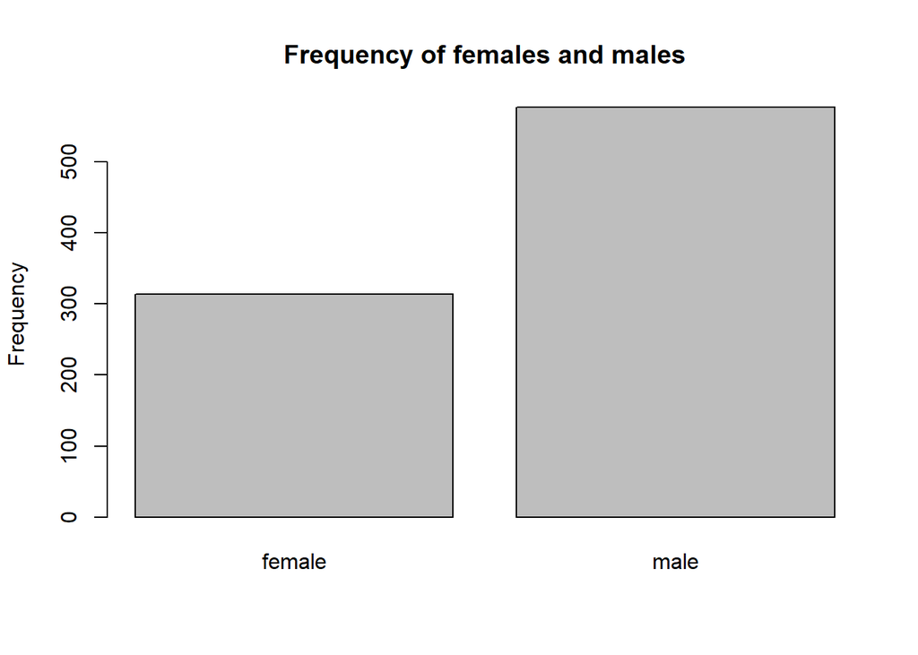

```r
plot(titanic$Sex,ylab = "Frequency",main="Frequency of females and males")
```

```r
tapply(titanic$Age,titanic$Survived,mean, na.rm=TRUE)
```

```
##        0        1
## 30.62618 28.34369
```

### 3. You research sleep and just got your first data set. Later,you’ll have another dataset with the same column names, so you want to create a helper function that you can analyze this dataset and the next. Load sleep_data_01.csv (found at http://talklab.psy.gla.ac.uk/L1_labs/lab_1/homework/index.html).

```r
sleep <- read.csv("sleep_data_01.csv",TRUE,",")
sleepfunction <-function(report){
MedianAge <- median(sleep$Age,na.rm = TRUE)
minsleep <- min(sleep$Duration,na.rm = TRUE)
maxsleep <- max(sleep$Duration,na.rm = TRUE)
meanrses <-mean(sleep$RSES,na.rm=TRUE)
sdrses <- sd(sleep$RSES,na.rm = TRUE)
return(data.frame(MedianAge = MedianAge/5,SelfEsteem = meanrses/5,SE_SD = sdrses,DurationRange = maxsleep - minsleep))
 }
sleepfunction()
```

```
##   MedianAge SelfEsteem    SE_SD DurationRange
## 1       2.8   3.622989 6.176522             7
```

```r
Report<-sleepfunction()
round(Report,digits = 2)
```

```
##   MedianAge SelfEsteem SE_SD DurationRange
## 1       2.8       3.62  6.18             7
```

### 4. FiveThirtyEight Data

```r
library(fivethirtyeight)
the538sets <-data(package = "fivethirtyeight")
df <-get(the538sets$results[22,"Item"])
dim(df)
```

```
## [1] 173  21
```

```r
colnames(df)
```

```
##  [1] "rank"                        "major_code"
##  [3] "major"                       "major_category"
##  [5] "total"                       "sample_size"
##  [7] "men"                         "women"
##  [9] "sharewomen"                  "employed"
## [11] "employed_fulltime"           "employed_parttime"
## [13] "employed_fulltime_yearround" "unemployed"
## [15] "unemployment_rate"           "p25th"
## [17] "median"                      "p75th"
## [19] "college_jobs"                "non_college_jobs"
## [21] "low_wage_jobs"
```

vignette(“fivethirtyeight”, package = “fivethirtyeight”)

### 5a. Write an R command that gives you the column names of the data frame. Right after that, write one that counts the number of columns but not rows.

```r
colnames(df)
```

```
##  [1] "rank"                        "major_code"
##  [3] "major"                       "major_category"
##  [5] "total"                       "sample_size"
##  [7] "men"                         "women"
##  [9] "sharewomen"                  "employed"
## [11] "employed_fulltime"           "employed_parttime"
## [13] "employed_fulltime_yearround" "unemployed"
## [15] "unemployment_rate"           "p25th"
## [17] "median"                      "p75th"
## [19] "college_jobs"                "non_college_jobs"
## [21] "low_wage_jobs"
```

```r
ncol(df)
```

```
## [1] 21
```

### 5b. Generate a count of each unique major_category in the data frame. I recommend using libraries to help. To be clear, this should look like a matrix or data frame containing the major_category and the frequency it occurs in the dataset. Assign it to major_count.

```r
major_count <-as.data.frame(table(df$major_category))
major_count
```

```
##                                   Var1 Freq
## 1      Agriculture & Natural Resources   10
## 2                                 Arts    8
## 3               Biology & Life Science   14
## 4                             Business   13
## 5          Communications & Journalism    4
## 6              Computers & Mathematics   11
## 7                            Education   16
## 8                          Engineering   29
## 9                               Health   12
## 10           Humanities & Liberal Arts   15
## 11 Industrial Arts & Consumer Services    7
## 12                   Interdisciplinary    1
## 13                 Law & Public Policy    5
## 14                   Physical Sciences   10
## 15            Psychology & Social Work    9
## 16                      Social Science    9
```

[figure not shown]

```r
par(las=2)
barplot(major_count$Freq, mainlab= "Major Category Breakdown", xlab= "Major", ylab= "Frequency",
names.arg= major_count$Var1,col =  rainbow(3),horiz = TRUE)
```

### 5d. Write the fivethirtyeight data to a csv file. Make sure that it does not have row labels.

`write.csv(df, "fivethirtyeight.csv", row.names=FALSE)`

### 6. In your RMarkdown script, please provide the link to this GitHub so the grader can see it.

https://github.com/sandman1145/SMU-MSDS-6306.git